# Query NWIS and Water Quality Portal for time series

Kelly Hondula

This notebook goes through searching the NWIS and WQP for time series of N, P, and chl.

```r
# devtools::install_github("USGS-R/dataRetrieval")
library(dataRetrieval)
library(dplyr)
library(lubridate)
library(glue)
library(ggplot2)
library(purrr)
library(readr)
library(DT)
```

Overview of data https://owi.usgs.gov/R/dataRetrieval.html#3

# Find Parameters Codes

There are 16,980 parameters, grouped into 16 categories and identified by unique 5 digit codes. Load the object `parameterCdFile` from the dataRetrieval package to browse them.

```r
parameterCdFile <- dataRetrieval::parameterCdFile
unique(parameterCdFile$parameter_group_nm)
```

[output not shown]

The column `parameter_nm` in the parameter code table contains longer descriptions. Use the `grep()` function to search the text in this column to find descriptions containing the word “phosphorus”.

## List of phosphorus codes

```r
phosCds_df <- parameterCdFile[grep("phosphorus",
                                parameterCdFile$parameter_nm,
                                ignore.case=TRUE),]
p_codes <- unique(phosCds_df$parameter_cd)
```

|  | parameter_cd | parameter_group_nm | parameter_nm | casrn | srsname | parameter_units |
| --- | --- | --- | --- | --- | --- | --- |
| 1331 | 99575 | Information | Sample volume, organophosphorus pesticides, water, filtered, milliliters |  |  | ml |
| 1332 | 99576 | Information | Set number, organophosphorus pesticides, water, filtered, number |  |  | nu |
| 1334 | 99578 | Information | Sample volume, organophosphorus pesticides, water, unfiltered, milliliters |  |  | ml |
| 1335 | 99579 | Information | Set number, organophosphorus pesticides, water, unfiltered, number |  |  | nu |
| 1337 | 99581 | Information | Sample weight, organophosphorus pesticides, bed sediment, grams |  |  | g |
| 1338 | 99582 | Information | Set number, organophosphorus pesticides, bed sediment, number |  |  | nu |
| 2739 | 00662 | Nutrient | Phosphorus, water, unfiltered, recoverable, micrograms per liter as phosphorus | 7723-14-0 |  | ug/l as P |
| 2740 | 00665 | Nutrient | Phosphorus, water, unfiltered, milligrams per liter as phosphorus | 7723-14-0 | Phosphorus | mg/l as P |
| 2741 | 00666 | Nutrient | Phosphorus, water, filtered, milligrams per liter as phosphorus | 7723-14-0 | Phosphorus | mg/l as P |
| 2742 | 00667 | Nutrient | Phosphorus, suspended sediment, total, milligrams per liter as phosphorus | 7723-14-0 | Phosphorus | mg/l as P |

[output cut: 83 more lines]

## List of nitrogen codes

```r
nitCds_df <- parameterCdFile[grep("nitrogen",
                                parameterCdFile$parameter_nm,
                                ignore.case=TRUE),]
n_codes <- unique(nitCds_df$parameter_cd)
```

|  | parameter_cd | parameter_group_nm | parameter_nm | casrn | srsname | parameter_units |
| --- | --- | --- | --- | --- | --- | --- |
| 1567 | 00321 | Physical | Ultimate nitrogenous biochemical oxygen demand, water, unfiltered, milligrams per liter |  | Nitrogenous biochemical oxygen demand | mg/l |
| 1750 | 61032 | Physical | Carbonaceous biochemical oxygen demand, water, filtered, nitrogen inhibited, 20 days at 20 degrees Celsius, milligrams per liter |  | Carbonaceous biochemical oxygen demand, non-standard conditions | mg/l |
| 1751 | 61168 | Physical | Carbonaceous biochemical oxygen demand, water, unfiltered, nitrogen inhibited, 20 days at 20 degrees Celsius, milligrams per liter |  | Carbonaceous biochemical oxygen demand, non-standard conditions | mg/l |
| 2017 | 82132 | Physical | Deoxygenation constant (k1 to base e), nitrogenous biochemical oxygen demand, water, unfiltered, 20 degrees Celsius, per day |  |  | 20C/day |
| 2019 | 82134 | Physical | Deoxygenation constant (k1 to base 10), nitrogenous biochemical oxygen demand, water, unfiltered, 20 degrees Celsius, per day |  |  | 20C/day |
| 2021 | 82136 | Physical | Reaction lag time, nitrogenous biochemical oxygen demand, water, unfiltered, 20 degrees Celsius, days |  |  | days |
| 2661 | 85548 | Inorganics, Major, Non-metals | Nitrogen plus carbon monoxide, water, dissolved, volume percent of dissolved gases |  |  | % |
| 2705 | 00597 | Nutrient | Dinitrogen, water, unfiltered, milligrams per liter | 7727-37-9 | Nitrogen | mg/l |
| 2706 | 00598 | Nutrient | Dinitrogen, water, unfiltered, percent of saturation | 7727-37-9 | Nitrogen | % |
| 2707 | 00600 | Nutrient | Total nitrogen [nitrate + nitrite + ammonia + organic-N], water, unfiltered, milligrams per liter |  | Nitrogen, mixed forms (NH3), (NH4), organic, (NO2) and (NO3) | mg/l |

[output cut: 168 more lines]

## List of chl codes

```r
chlCds_df <- parameterCdFile[grep("chlorophyll",
                                parameterCdFile$parameter_nm,
                                ignore.case=TRUE),]
chl_codes <- unique(chlCds_df$parameter_cd)
```

|  | parameter_cd | parameter_group_nm | parameter_nm | casrn | srsname | parameter_units |
| --- | --- | --- | --- | --- | --- | --- |
| 1655 | 32315 | Physical | Chlorophyll fluorescence (fChl), water, in situ, relative fluorescence units (RFU) | 479-61-8 | Chlorophyll a | RFU |
| 1656 | 32316 | Physical | Chlorophyll fluorescence (fChl), water, in situ, micrograms per liter as chlorophyll | 479-61-8 | Chlorophyll a | ug/l |
| 3316 | 32209 | Biological | Chlorophyll a, water, fluorometric method, corrected, micrograms per liter | 479-61-8 | Chlorophyll a | ug/l |
| 3317 | 32210 | Biological | Chlorophyll a, water, trichromatic method, uncorrected, micrograms per liter | 479-61-8 | Chlorophyll a | ug/l |
| 3318 | 32211 | Biological | Chlorophyll a, phytoplankton, spectrophotometric acid method, micrograms per liter | 479-61-8 | Chlorophyll a | ug/l |
| 3320 | 32217 | Biological | Chlorophyll a, fluorometric method, uncorrected, micrograms per liter | 479-61-8 | Chlorophyll a | ug/l |
| 3322 | 32223 | Biological | Chlorophyll a, periphyton, spectrophotometric method, corrected, milligrams per square meter | 479-61-8 | Chlorophyll a | mg/m2 |
| 3324 | 32225 | Biological | Chlorophylls, periphyton, spectrophotometric method, uncorrected, milligrams per square meter | 1406-65-1 | Chlorophyll | mg/m2 |
| 3325 | 32226 | Biological | Chlorophyll b, periphyton, spectrophotometric method, uncorrected, milligrams per square meter | 519-62-0 | Chlorophyll b | mg/m2 |
| 3326 | 32227 | Biological | Chlorophyll c, periphyton, spectrophotometric method, uncorrected, milligrams per square meter | 11003-45-5 | Chlorophyll c | mg/m2 |

[output cut: 44 more lines]

# NWIS water quality data

There needs to be at least one “major” filter for searching NWIS data. Strategy is to go through all the states to get a table of what is available through NWIS, using the built in vector of state abbreviations (`state.abb`)

Define function to save a csv file based on a state and set of parameter codes. use a code for the file name

```r
save_10yr_ts_nwis <- function(state_abbrev, my_codes, my_codes_cat = "chl"){
  whatNWISdata(stateCd = state_abbrev,
  parameterCd = my_codes) %>%
  mutate(date_range_interval = ymd(begin_date) %--% ymd(end_date),
         date_range_yrs = suppressMessages(as.period(date_range_interval))/years()) %>%
  dplyr::filter(date_range_yrs > 10) %>%
  arrange(rev(date_range_yrs)) %>%
  readr::write_csv(glue("data/nwis_query_{my_codes_cat}-{state_abbrev}.csv"))
}
```

Use function to save file for each state and set of codes

```r
purrr::walk(state.abb, ~save_10yr_ts_nwis(state_abbrev = .x,
                                     my_codes = chl_codes,
                                     my_codes_cat = "chl"))

purrr::walk(state.abb, ~save_10yr_ts_nwis(state_abbrev = .x,
                                     my_codes = p_codes,
                                     my_codes_cat = "phos"))

# max 100 parameter codes so split up n codes
purrr::walk(state.abb, ~save_10yr_ts_nwis(state_abbrev = .x,
                                     my_codes = n_codes[1:100],
                                     my_codes_cat = "nitr1"))

purrr::walk(state.abb, ~save_10yr_ts_nwis(state_abbrev = .x,
                                     my_codes = n_codes[101:178],
                                     my_codes_cat = "nitr2"))
```

Read in all separate state files and combine, then Join with site codes information to convert parameter codes to names

```r
par_codes_for_join <- dplyr::select(parameterCdFile, parameter_cd,
                                    parameter_nm, parameter_units)

nwis_chl_ts <- purrr::map_df(fs::dir_ls("data", regexp = "nwis.*chl"), ~readr::read_csv(.x, col_types = c("ccccddcccccc?c?c???c?DDn?n"))) %>%
  left_join(par_codes_for_join, by = c("parm_cd" = "parameter_cd"))

nwis_phos_ts <- purrr::map_df(fs::dir_ls("data", regexp = "nwis.*phos"), ~readr::read_csv(.x, col_types = c("ccccddcccccc?c?c???c?DDn?n"))) %>%
  left_join(par_codes_for_join, by = c("parm_cd" = "parameter_cd"))

nwis_nitr_ts <- purrr::map_df(fs::dir_ls("data", regexp = "nwis.*nitr"), ~readr::read_csv(.x, col_types = c("ccccddcccccc?c?c???c?DDn?n"))) %>%
  left_join(par_codes_for_join, by = c("parm_cd" = "parameter_cd"))
```

Save combined file

```r
readr::write_csv(nwis_chl_ts, "chl_nwis_ts.csv")
readr::write_csv(nwis_phos_ts, "phos_nwis_ts.csv")
readr::write_csv(nwis_nitr_ts, "nitr_nwis_ts.csv")
```

## Get data values from NWIS

Example of getting data from one row of time series data frame with `readNWISqw` function.

```r
my_site <-  nwis_chl_ts$site_no[2]
my_param <- nwis_chl_ts$parm_cd[2]

chl_nwis_data_ex <- readNWISqw(siteNumbers = my_site,
                     parameterCd = my_param)
```

## Plot NWIS data

use attributes of the returned data frame

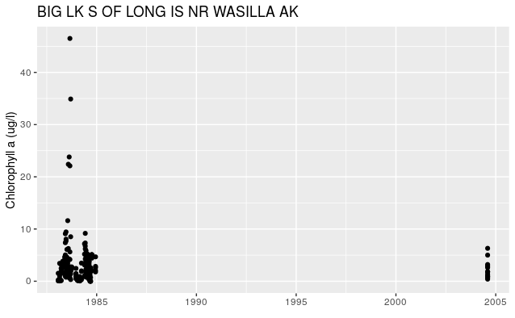

```r
varInfo <- attributes(chl_nwis_data_ex)[["variableInfo"]]
siteInfo <- attributes(chl_nwis_data_ex)[["siteInfo"]]

chl_nwis_data_ex %>%
  ggplot(aes(x = startDateTime, y = result_va)) +
  geom_point() +
  ylab(glue('{varInfo$srsname} ({varInfo$parameter_units})')) +
  xlab(element_blank()) +
  ggtitle(siteInfo$station_nm)
```

# Water Quality Portal

That was searching NWIS, which is USGS data. The water quality portal includes data from states, EPA, USDA, etc. Note details about differences here: https://owi.usgs.gov/R/dataRetrieval.html#23.

> There’s not a function in WQP that returns period of record information like we did above via NWIS data…(that feature may be implemented in the future). The following function returns sites that have collected phosphorus data in Wisconsin. There’s no way to know if that site has collected one sample, or thousands.

Need to use characteristic names for all of WQP which [only seem to be available](https://github.com/USGS-R/dataRetrieval/issues/417) here: https://www.waterqualitydata.us/Codes/Characteristicname?mimeType=xml

**MonitoringLocationIdentifier**: A designator used to describe the unique name, number, or code assigned to identify the monitoring location.

```r
is.null(char_Data)
```

```
[1] TRUE
```

```r
purrr::walk(state.abb, ~save_10yr_ts_wqp(state_abbrev = .x,
                                     char_name = "Phosphorus",
                                     my_codes_cat = "phos"
                                     ))

purrr::walk(state.abb, ~save_10yr_ts_wqp(state_abbrev = .x,
                                     char_name = "Chlorophyll",
                                     my_codes_cat = "chl"))

purrr::walk(state.abb, ~save_10yr_ts_wqp(state_abbrev = .x,
                                     char_name = "Nitrogen",
                                     my_codes_cat = "nitr"))
```

Read in groups of CSV files to save summary tables for all states for each parameter

```r
wqp_chl_ts <- purrr::map_df(fs::dir_ls("data", regexp = "wqp.*chl"),
                              ~readr::read_csv(.x, col_types = wqp_col_types))
```

```
Error: Column `SourceMapScaleNumeric` can't be converted from character to numeric
```